# FINAL PROJECT

GROUP - 2

2022-12-08

```r
library(readr)
library(tidyverse)
library(caret)
library(pROC)
```

```r
library(ggcorrplot)
library(party)
library(rpart)
library(RANN)
library(rpart.plot)
library(class)
library(dplyr)
library(tidyr)
library(rattle)
library(corrplot)
library(ranger)
```

#Importing the Churn dataset

```r
Churn_Train<- read.csv("C:/Users/Nikitha/Downloads/Churn_Train.csv")
str(Churn_Train)
```

```
## 'data.frame':    3333 obs. of  20 variables:
##  $ state                        : chr  "NV" "HI" "DC" "HI" ...
##  $ account_length               : int  125 108 82 NA 83 89 135 28 86 65 ...
##  $ area_code                    : chr  "area_code_510" "area_code_415" "area_code_415" "area_code_408" ...
##  $ international_plan           : chr  "no" "no" "no" "no" ...
##  $ voice_mail_plan              : chr  "no" "no" "no" "yes" ...
##  $ number_vmail_messages        : int  0 0 0 30 0 0 0 0 0 0 ...
##  $ total_day_minutes            : num  2013 292 300 110 337 ...
##  $ total_day_calls              : int  99 99 109 71 120 81 81 87 115 137 ...
##  $ total_day_charge             : num  28.7 49.6 51 18.8 57.4 ...
##  $ total_eve_minutes            : num  1108 221 181 182 227 ...
##  $ total_eve_calls              : int  107 93 100 108 116 74 114 92 112 83 ...
##  $ total_eve_charge             : num  14.9 18.8 15.4 15.5 19.3 ...
##  $ total_night_minutes          : num  243 229 270 184 154 ...
##  $ total_night_calls            : int  92 110 73 88 114 120 82 112 95 111 ...
##  $ total_night_charge           : num  10.95 10.31 12.15 8.27 6.93 ...
##  $ total_intl_minutes           : num  10.9 14 11.7 11 15.8 9.1 10.3 10.1 9.8 12.7 ...
##  $ total_intl_calls             : int  7 9 4 8 7 4 6 3 7 6 ...
##  $ total_intl_charge            : num  2.94 3.78 3.16 2.97 4.27 2.46 2.78 2.73 2.65 3.43 ...
##  $ number_customer_service_calls: int  0 2 0 2 0 1 1 3 2 4 ...
##  $ churn                        : chr  "no" "yes" "yes" "no" ...
```

```r
#showing the Summary of statistics in the dataset
summary(Churn_Train)
```

```
##     state           account_length     area_code         international_plan
##  Length:3333        Min.   :-209.00   Length:3333        Length:3333
##  Class :character   1st Qu.:  72.00   Class :character   Class :character
##  Mode  :character   Median : 100.00   Mode  :character   Mode  :character
##                     Mean   :  97.32
##                     3rd Qu.: 127.00
##                     Max.   : 243.00
##                     NA's   :501
##  voice_mail_plan    number_vmail_messages total_day_minutes total_day_calls
##  Length:3333        Min.   :-10.000       Min.   :   0.0    Min.   :  0.0
##  Class :character   1st Qu.:  0.000       1st Qu.: 149.3    1st Qu.: 87.0
##  Mode  :character   Median :  0.000       Median : 190.5    Median :101.0
##                     Mean   :  7.333       Mean   : 418.9    Mean   :100.3
##                     3rd Qu.: 16.000       3rd Qu.: 237.8    3rd Qu.:114.0
##                     Max.   : 51.000       Max.   :2185.1    Max.   :165.0
##                     NA's   :200           NA's   :200       NA's   :200
##  total_day_charge total_eve_minutes total_eve_calls total_eve_charge
##  Min.   : 0.00    Min.   :   0.0    Min.   :  0.0   Min.   : 0.00
##  1st Qu.:24.45    1st Qu.: 170.5    1st Qu.: 87.0   1st Qu.:14.14
##  Median :30.65    Median : 209.9    Median :100.0   Median :17.09
##  Mean   :30.63    Mean   : 324.3    Mean   :100.1   Mean   :17.08
##  3rd Qu.:36.84    3rd Qu.: 257.6    3rd Qu.:114.0   3rd Qu.:20.00
##  Max.   :59.64    Max.   :1244.2    Max.   :170.0   Max.   :30.91
##  NA's   :200      NA's   :301       NA's   :200     NA's   :200
##  total_night_minutes total_night_calls total_night_charge total_intl_minutes
##  Min.   : 23.2       Min.   : 33.0     Min.   : 1.040     Min.   : 0.00
##  1st Qu.:167.3       1st Qu.: 87.0     1st Qu.: 7.530     1st Qu.: 8.50
##  Median :201.4       Median :100.0     Median : 9.060     Median :10.30
##  Mean   :201.2       Mean   :100.1     Mean   : 9.054     Mean   :10.23
##  3rd Qu.:235.3       3rd Qu.:113.0     3rd Qu.:10.590     3rd Qu.:12.10
##  Max.   :395.0       Max.   :175.0     Max.   :17.770     Max.   :20.00
##  NA's   :200                           NA's   :200        NA's   :200
##  total_intl_calls total_intl_charge number_customer_service_calls
##  Min.   : 0.00    Min.   :0.000     Min.   :0.000
##  1st Qu.: 3.00    1st Qu.:2.300     1st Qu.:1.000
##  Median : 4.00    Median :2.780     Median :1.000
##  Mean   : 4.47    Mean   :2.762     Mean   :1.561
##  3rd Qu.: 6.00    3rd Qu.:3.270     3rd Qu.:2.000
##  Max.   :20.00    Max.   :5.400     Max.   :9.000
##  NA's   :301      NA's   :200       NA's   :200
##     churn
##  Length:3333
##  Class :character
##  Mode  :character
##
##
##
##
```

#Converting the categorical variables to numeric

```r
Churn_Train$international_plan <- as.factor(Churn_Train$international_plan)
Churn_Train$voice_mail_plan <- as.factor(Churn_Train$voice_mail_plan)
Churn_Train$churn <- as.factor(Churn_Train$churn)
Churn_Train$state <- as.factor(Churn_Train$state)
Churn_Train$area_code <- as.factor(Churn_Train$area_code)

Churn_true  <- subset(Churn_Train, Churn_Train$churn == "yes")
Churn_false <- subset(Churn_Train, Churn_Train$churn == "no")
```

```r
#Number of churn count of Yes/No
Count_Churn<-table(Churn_Train$churn)
Count_Churn
```

```
##
##   no  yes
## 2850  483
```

#Checking the skewness,Distribution of each variable in the dataset

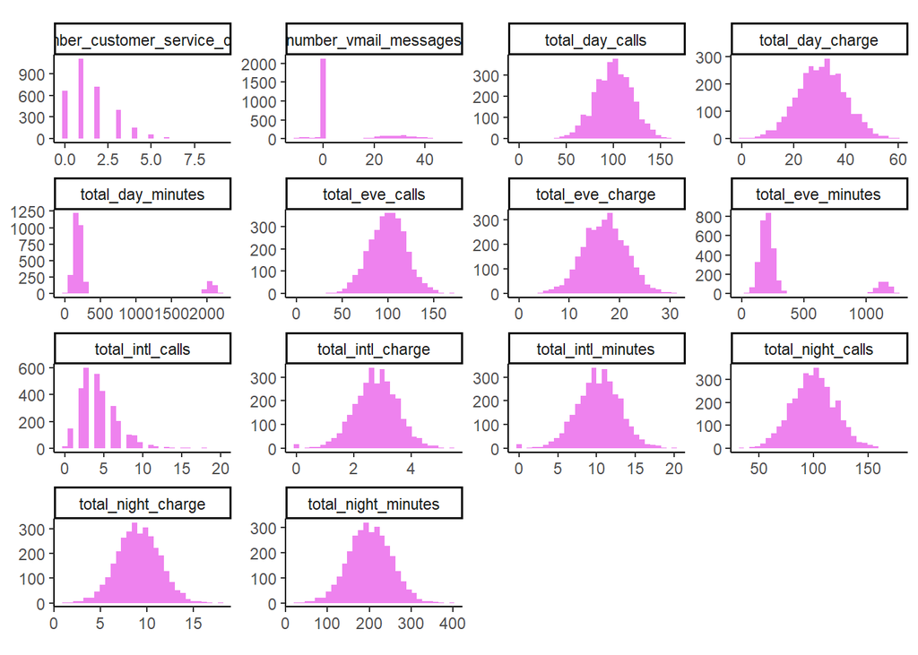

```r
Churn_Train[, 6:19] %>%
  gather(key = Variable, value = Value) %>%
  ggplot() +
  geom_histogram(aes(x = Value), fill = "violet") +
  facet_wrap(~Variable, scales='free') +
  theme_classic() +
  theme(aspect.ratio = 0.5, axis.title = element_blank(), panel.grid = element_blank())
```

The above skewness shows a bell curve distribution of data for maximum amount of the data or variables. It is seen that the “Total day minutes” and “Total evening minutes” have a significant Number of outliers. It is evident “Customer_Service_calls” has an irregular skewness.

#Determining the number of customer churn

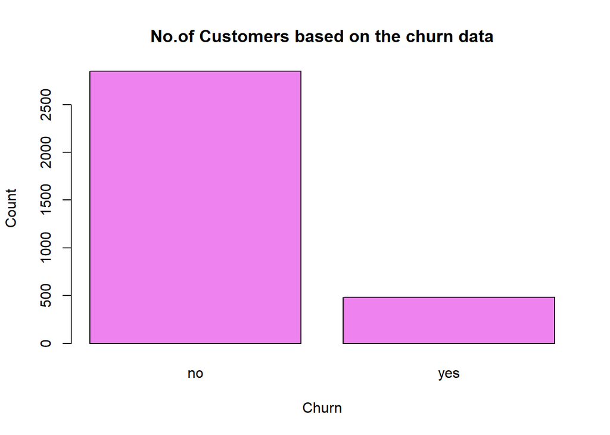

```r
barplot(Count_Churn,xlab ="Churn",ylab="Count" ,col = "violet" ,main = "No.of Customers based on the churn data")
```

The customer churn analyzed is 483 out of 3333.Which is 2850 customers have stayed with the current provider.

#Determining the number of customers based on the Area code

```r
C_Count_area_code <- Churn_true %>% group_by(area_code) %>% summarise(Churn_area_code_count = n())
Churnonareacode <- Churn_Train %>% group_by(Churn_Train$area_code, Churn_Train$churn) %>% summarise(count =n())
```

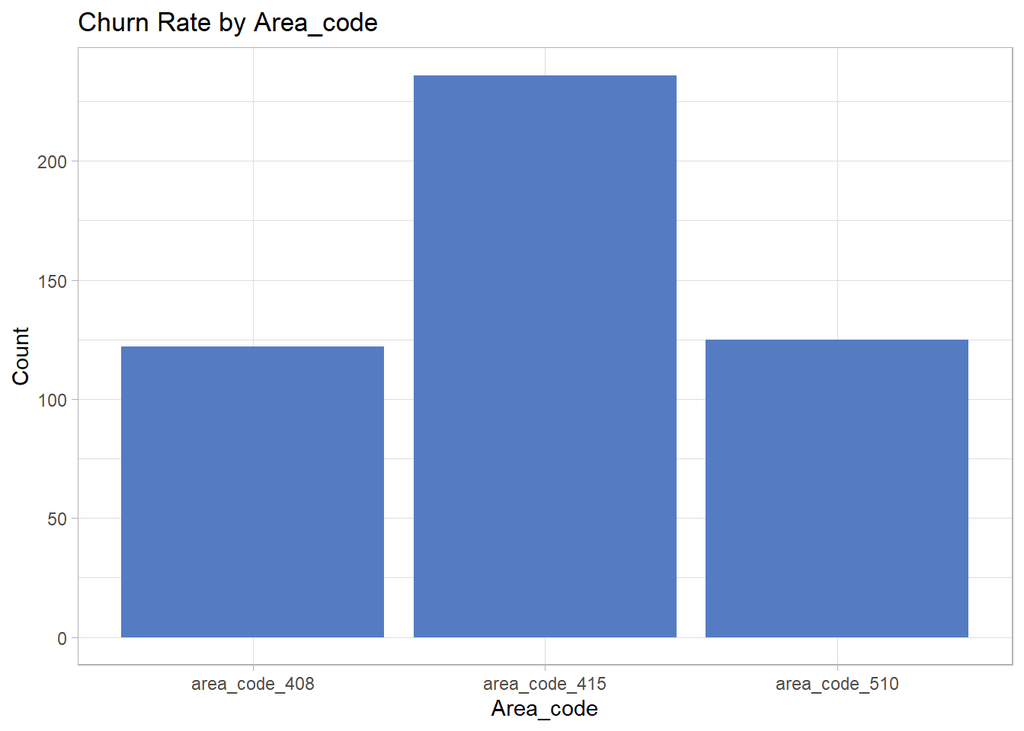

```r
ggplot(C_Count_area_code) +
  aes(x = area_code, weight = Churn_area_code_count) +
  geom_bar(fill = "#557CC2") +
  labs(x = "Area_code", y = "Count", title = "Churn Rate by Area_code") +
  theme_light()
```

The area_code_415 has the highest of customer churn rate.

#Determining the number of customer churn by the international charge

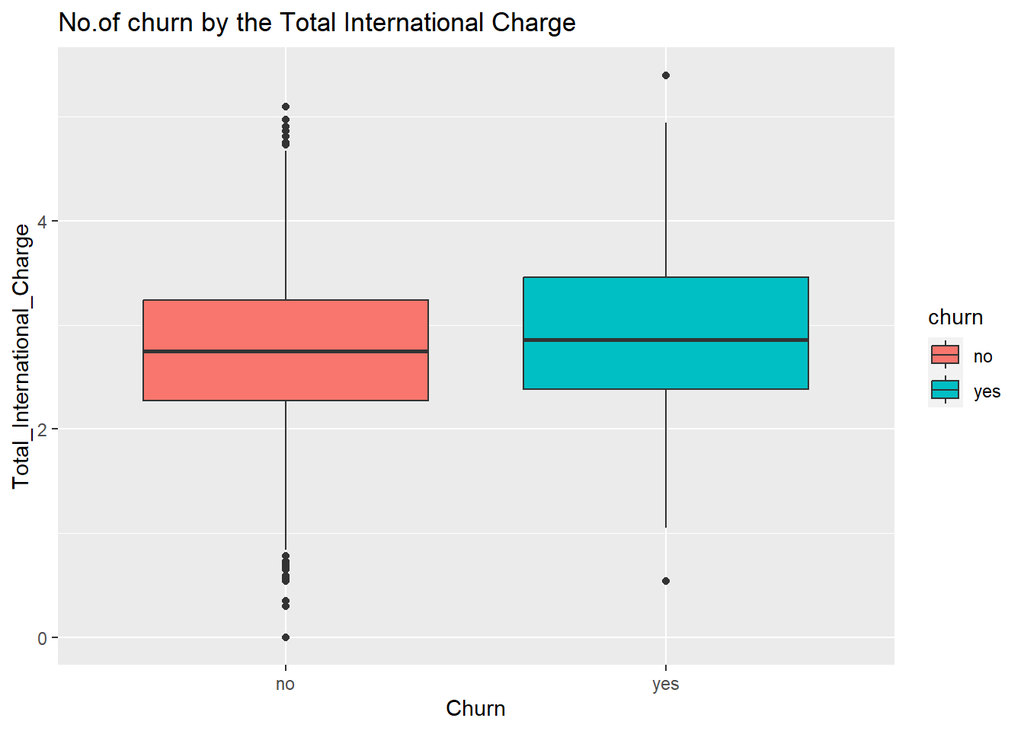

```r
ggplot(Churn_Train) +
  aes(x = churn, y = total_intl_charge , fill = churn) +
  geom_boxplot(shape = "Square") +
  scale_fill_hue(direction = 1) +
  labs(x = "Churn", y = "Total_International_Charge",title = "No.of churn by the Total International Charge")
```

```r
  theme_minimal()+
  theme(plot.title = element_text(size = 10L,
                                  face = "bold", hjust = 0.5))
```

[output not shown]

[output cut: 330 more lines]

[output not shown]

#Determine the number of customers churn due to international plan and voice mail plans.

```r
table(International_plan=Churn_Train$international_plan,
      Churn= Churn_Train$churn )
```

```
##                   Churn
## International_plan   no  yes
##                no  2664  346
##                yes  186  137
```

```r
table( voice__mail__plan=   Churn_Train$voice_mail_plan,
       Churn_Train$churn)
```

```
##
## voice__mail__plan   no  yes
##               no  2008  403
##               yes  842   80
```

28% of customers are lost by the International plan and 16% of customers are lost by the voice mail plan.

#Data Cleaning:-

```r
#Filling the missing value with mice package
sum(is.na(Churn_Train))
```

```
## [1] 3303
```

```r
Churn_Train<-Churn_Train[complete.cases(Churn_Train),]
colMeans(is.na(Churn_Train))
```

```
##                         state                account_length
##                             0                             0
##                     area_code            international_plan
##                             0                             0
##               voice_mail_plan         number_vmail_messages
##                             0                             0
##             total_day_minutes               total_day_calls
##                             0                             0
##              total_day_charge             total_eve_minutes
##                             0                             0
##               total_eve_calls              total_eve_charge
##                             0                             0
##           total_night_minutes             total_night_calls
##                             0                             0
##            total_night_charge            total_intl_minutes
##                             0                             0
##              total_intl_calls             total_intl_charge
##                             0                             0
## number_customer_service_calls                         churn
##                             0                             0
```

```r
str(Churn_Train)
```

```
## 'data.frame':    2630 obs. of  20 variables:
##  $ state                        : Factor w/ 51 levels "AK","AL","AR",..: 34 12 8 36 28 39 13 9 18 26 ...
##  $ account_length               : int  125 108 82 83 135 28 86 125 106 131 ...
##  $ area_code                    : Factor w/ 3 levels "area_code_408",..: 3 2 2 2 2 2 1 1 3 2 ...
##  $ international_plan           : Factor w/ 2 levels "no","yes": 1 1 1 1 1 1 1 1 1 1 ...
##  $ voice_mail_plan              : Factor w/ 2 levels "no","yes": 1 1 1 1 1 1 1 1 2 1 ...
##  $ number_vmail_messages        : int  0 0 0 0 0 0 0 0 9 0 ...
##  $ total_day_minutes            : num  2013 292 300 337 202 ...
##  $ total_day_calls              : int  99 99 109 120 81 87 115 108 100 95 ...
##  $ total_day_charge             : num  28.7 49.6 51 57.4 34.3 ...
##  $ total_eve_minutes            : num  1108 221 181 227 225 ...
##  $ total_eve_calls              : int  107 93 100 116 114 92 112 90 109 109 ...
##  $ total_eve_charge             : num  14.9 18.8 15.4 19.3 19.1 ...
##  $ total_night_minutes          : num  243 229 270 154 204 ...
##  $ total_night_calls            : int  92 110 73 114 82 112 95 114 86 129 ...
##  $ total_night_charge           : num  10.95 10.31 12.15 6.93 9.2 ...
##  $ total_intl_minutes           : num  10.9 14 11.7 15.8 10.3 10.1 9.8 13.3 8.2 15.5 ...
##  $ total_intl_calls             : int  7 9 4 7 6 3 7 7 4 3 ...
##  $ total_intl_charge            : num  2.94 3.78 3.16 4.27 2.78 2.73 2.65 3.59 2.21 4.19 ...
##  $ number_customer_service_calls: int  0 2 0 0 1 3 2 1 3 1 ...
##  $ churn                        : Factor w/ 2 levels "no","yes": 1 2 2 2 1 1 1 1 1 2 ...
```

```r
churn_yes<-Churn_Train %>% filter(churn=='yes')
```

#Corrleation plot

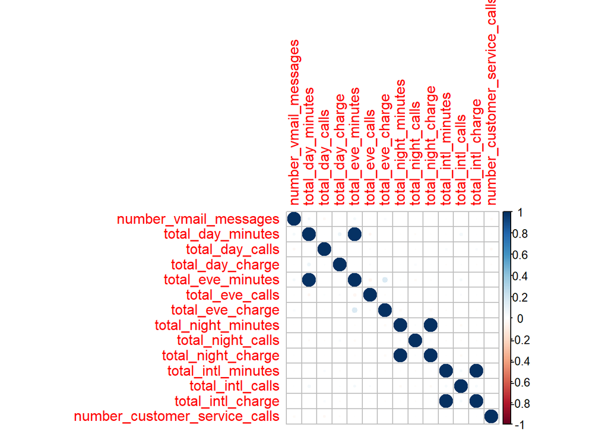

```r
Churn_Train_Num <- Churn_Train[6:19]
corrplot(cor(Churn_Train_Num))
```

#Data Partitioning

```r
set.seed(123)
Index<- createDataPartition(Churn_Train$churn,p=0.8,list=FALSE)
Train<-Churn_Train[Index,]
Validation <- Churn_Train[-Index,]
```

#Building a Logistic Regression model:-

```r
set.seed(123)
Logistic_Model <- glm(churn~.,data=Train ,family = "binomial" )

#summary Logistic_Model
pred_Validation<-predict(Logistic_Model,Validation,type="response")
head(pred_Validation)
```

```
##          5          8         26         35         36         44
## 0.25939234 0.15373511 0.01128172 0.02619599 0.15271657 0.61886558
```

```r
Resultcheck1<-ifelse(pred_Validation > 0.5,'yes','no')
```

```r
#Accuracy Check
Error1<-mean(Resultcheck1!=Validation$churn)
Acc1 <-1- Error1
print(Acc1)
```

```
## [1] 0.8821293
```

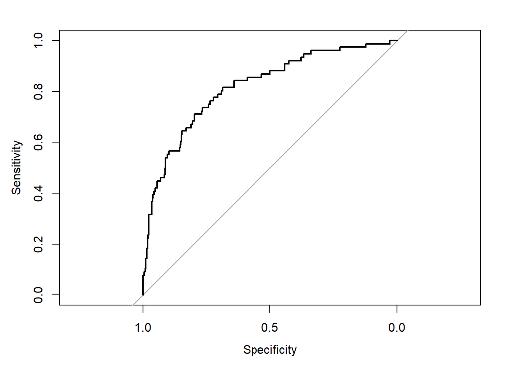

```r
#Plotting the ROC (Receiver Operating Characteristic)
plot.roc(Validation$churn,pred_Validation)
```

#Confusion Matrix of Logistic Regression Model

```r
set.seed(123)
Logistic_Confusionmatrix <- confusionMatrix(as.factor(Resultcheck1),as.factor(Validation$churn))
Logistic_Confusionmatrix
```

```
## Confusion Matrix and Statistics
##
##           Reference
## Prediction  no yes
##        no  440  52
##        yes  10  24
##
##                Accuracy : 0.8821
##                  95% CI : (0.8515, 0.9084)
##     No Information Rate : 0.8555
##     P-Value [Acc > NIR] : 0.04422
##
##                   Kappa : 0.3811
##
##  Mcnemar's Test P-Value : 1.919e-07
##
##             Sensitivity : 0.9778
##             Specificity : 0.3158
##          Pos Pred Value : 0.8943
##          Neg Pred Value : 0.7059
##              Prevalence : 0.8555
##          Detection Rate : 0.8365
##    Detection Prevalence : 0.9354
##       Balanced Accuracy : 0.6468
##
##        'Positive' Class : no
##
```

#Building a Decision Tree Model

```r
set.seed(123)
Decision_Tree_Model<- rpart(churn ~ .,data=Train,method = 'class')
head(Decision_Tree_Model$splits)
```

```
##                               count ncat  improve  index adj
## total_day_charge               2104   -1 59.19097  41.64   0
## number_customer_service_calls  2104   -1 46.31167   3.50   0
## international_plan             2104    2 35.82882   1.00   0
## total_day_minutes              2104   -1 20.69374 223.25   0
## state                          2104   51 12.76999   2.00   0
## number_customer_service_calls  1850   -1 51.63091   3.50   0
```

```r
#Predicting the probability
Prob_Decision_Tree <- predict(Decision_Tree_Model, newdata = Validation, type = "prob")
```

```r
#Determining AUC Value
roc(Validation$churn,Prob_Decision_Tree[,2])
```

```
##
## Call:
## roc.default(response = Validation$churn, predictor = Prob_Decision_Tree[,     2])
##
## Data: Prob_Decision_Tree[, 2] in 450 controls (Validation$churn no) < 76 cases (Validation$churn yes).
## Area under the curve: 0.9135
```

#Confusion Matrix for Decision Tree Model

```r
set.seed(123)
Class_Decision_Tree <- predict(Decision_Tree_Model, newdata = Validation, type = "class")
confusionMatrix(as.factor(Class_Decision_Tree),as.factor(Validation$churn))
```

```
## Confusion Matrix and Statistics
##
##           Reference
## Prediction  no yes
##        no  439  23
##        yes  11  53
##
##                Accuracy : 0.9354
##                  95% CI : (0.9108, 0.9548)
##     No Information Rate : 0.8555
##     P-Value [Acc > NIR] : 7.614e-09
##
##                   Kappa : 0.7202
##
##  Mcnemar's Test P-Value : 0.05923
##
##             Sensitivity : 0.9756
##             Specificity : 0.6974
##          Pos Pred Value : 0.9502
##          Neg Pred Value : 0.8281
##              Prevalence : 0.8555
##          Detection Rate : 0.8346
##    Detection Prevalence : 0.8783
##       Balanced Accuracy : 0.8365
##
##        'Positive' Class : no
##
```

From the above model, the Decision Tree Model is the optimal model for this dataset. It is the best model to use as it has higher accuracy than the Logistical Regression Model. Though the Sensitivities of both the models are equal, Decision Tree has a higher specificity. Hence, Decision Tree Model is the right and optimal Model to use.

```r
set.seed(123)
ABC_Wireless_Model<- rpart(churn ~ .,data= Churn_Train,method = 'class')
```

```r
#Determining the Model Splits.
head(ABC_Wireless_Model$splits)
```

```
##                               count ncat  improve   index adj
## total_day_charge               2630   -1 80.32294  44.975   0
## number_customer_service_calls  2630   -1 58.53763   3.500   0
## international_plan             2630    2 46.95324   1.000   0
## total_day_minutes              2630   -1 27.09291 223.250   0
## state                          2630   51 13.72057   2.000   0
## number_customer_service_calls  2453   -1 59.38012   3.500   0
```

[figure not shown]

```r
#Plotting Decision Tree
fancyRpartPlot(ABC_Wireless_Model)
```

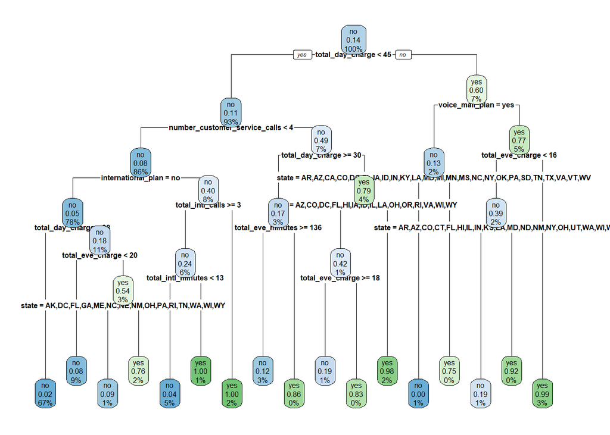

```r
rpart.plot(ABC_Wireless_Model, cex=0.5)
```

```r
#Probability Prediction
Prob_decision_tree <- predict(ABC_Wireless_Model, newdata = Churn_Train, type = "prob")

#Determining the AUC Value
roc(Churn_Train$churn,Prob_decision_tree[,2])
```

```
##
## Call:
## roc.default(response = Churn_Train$churn, predictor = Prob_decision_tree[,     2])
##
## Data: Prob_decision_tree[, 2] in 2250 controls (Churn_Train$churn no) < 380 cases (Churn_Train$churn yes).
## Area under the curve: 0.9222
```

```r
set.seed(123)
load("C:\\Users\\Nikitha\\Downloads\\Customers_To_Predict.RData")

dim(Customers_To_Predict)
```

```
## [1] 1600   19
```

```r
count(Customers_To_Predict)
```

```
## # A tibble: 1 x 1
##       n
##   <int>
## 1  1600
```

```r
summary(Customers_To_Predict)
```

```
##     state           account_length    area_code         international_plan
##  Length:1600        Min.   :  1.00   Length:1600        Length:1600
##  Class :character   1st Qu.: 71.00   Class :character   Class :character
##  Mode  :character   Median : 98.00   Mode  :character   Mode  :character
##                     Mean   : 98.52
##                     3rd Qu.:126.00
##                     Max.   :238.00
##  voice_mail_plan    number_vmail_messages total_day_minutes total_day_calls
##  Length:1600        Min.   : 0.000        Min.   :  6.6     Min.   : 34.00
##  Class :character   1st Qu.: 0.000        1st Qu.:143.8     1st Qu.: 86.00
##  Mode  :character   Median : 0.000        Median :180.9     Median : 99.00
##                     Mean   : 7.043        Mean   :181.6     Mean   : 99.06
##                     3rd Qu.: 0.000        3rd Qu.:215.9     3rd Qu.:112.00
##                     Max.   :52.000        Max.   :351.5     Max.   :160.00
##  total_day_charge total_eve_minutes total_eve_calls total_eve_charge
##  Min.   : 1.12    Min.   : 22.3     Min.   : 38.0   Min.   : 1.90
##  1st Qu.:24.45    1st Qu.:165.8     1st Qu.: 88.0   1st Qu.:14.10
##  Median :30.76    Median :199.9     Median :101.0   Median :17.00
##  Mean   :30.87    Mean   :199.6     Mean   :100.6   Mean   :16.96
##  3rd Qu.:36.70    3rd Qu.:231.8     3rd Qu.:114.0   3rd Qu.:19.70
##  Max.   :59.76    Max.   :359.3     Max.   :169.0   Max.   :30.54
##  total_night_minutes total_night_calls total_night_charge total_intl_minutes
##  Min.   :  0.0       Min.   :  0.00    Min.   : 0.000     Min.   : 0.00
##  1st Qu.:166.6       1st Qu.: 86.00    1st Qu.: 7.500     1st Qu.: 8.60
##  Median :199.2       Median : 99.00    Median : 8.960     Median :10.40
##  Mean   :199.2       Mean   : 99.45    Mean   : 8.963     Mean   :10.32
##  3rd Qu.:232.4       3rd Qu.:113.00    3rd Qu.:10.463     3rd Qu.:12.00
##  Max.   :381.6       Max.   :170.00    Max.   :17.170     Max.   :19.70
##  total_intl_calls total_intl_charge number_customer_service_calls
##  Min.   : 0.000   Min.   :0.000     Min.   :0.000
##  1st Qu.: 3.000   1st Qu.:2.320     1st Qu.:1.000
##  Median : 4.000   Median :2.810     Median :1.000
##  Mean   : 4.356   Mean   :2.786     Mean   :1.583
##  3rd Qu.: 5.000   3rd Qu.:3.240     3rd Qu.:2.000
##  Max.   :19.000   Max.   :5.320     Max.   :7.000
```

```r
# Check for NA Values
colMeans(is.na(Customers_To_Predict))
```

```
##                         state                account_length
##                             0                             0
##                     area_code            international_plan
##                             0                             0
##               voice_mail_plan         number_vmail_messages
##                             0                             0
##             total_day_minutes               total_day_calls
##                             0                             0
##              total_day_charge             total_eve_minutes
##                             0                             0
##               total_eve_calls              total_eve_charge
##                             0                             0
##           total_night_minutes             total_night_calls
##                             0                             0
##            total_night_charge            total_intl_minutes
##                             0                             0
##              total_intl_calls             total_intl_charge
##                             0                             0
## number_customer_service_calls
##                             0
```

```r
Churn_Prob <- predict(ABC_Wireless_Model,Customers_To_Predict,type = "prob")
head(Churn_Prob)
```

```
##          no        yes
## 1 0.9760684 0.02393162
## 2 0.9760684 0.02393162
## 3 0.9760684 0.02393162
## 4 0.9615385 0.03846154
## 5 0.9760684 0.02393162
## 6 0.0156250 0.98437500
```

```r
Predict_Churn <- predict(ABC_Wireless_Model,Customers_To_Predict,type = "class")
head(Predict_Churn)
```

```
##   1   2   3   4   5   6
##  no  no  no  no  no yes
## Levels: no yes
```

```r
Predict_Churn<- as.data.frame(Predict_Churn)
summary(Predict_Churn)
```

```
##  Predict_Churn
##  no :1432
##  yes: 168
```

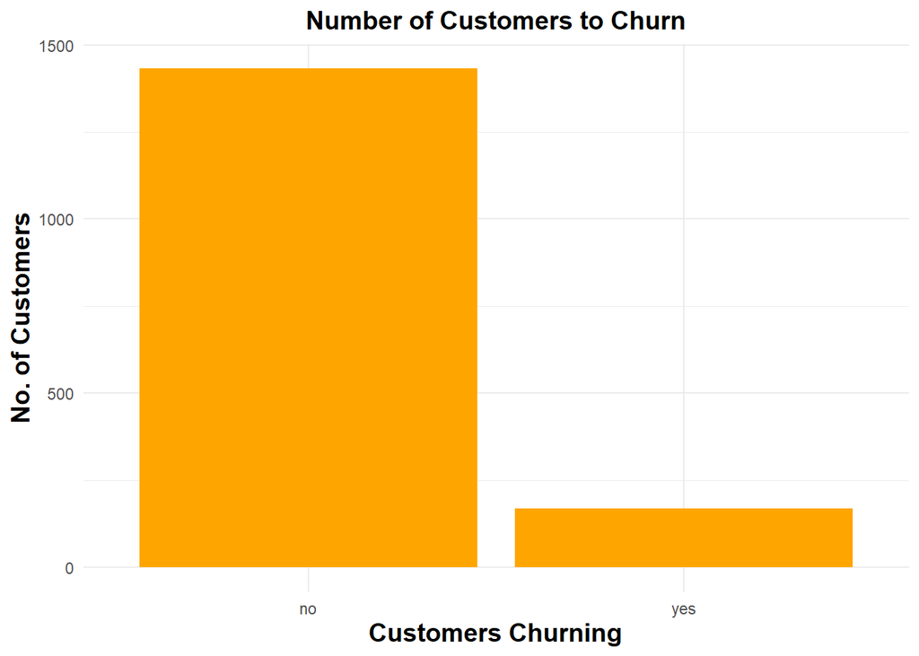

```r
ggplot(Predict_Churn) +
 aes(x = Predict_Churn) +
 geom_bar(fill = "orange")+
 labs(x = "Customers Churning",
 y = "No. of Customers", title = "Number of Customers to Churn") +
 theme_minimal() +
 theme(plot.title = element_text(size = 14L,
 face = "bold", hjust = 0.5), axis.title.y = element_text(size = 14L, face = "bold"), axis.title.x = element_text(size = 14L,face = "bold"))
```

From the above, it is concluded that 168 customers are churning out of 1600 customers.